# EDA buscas

```r
library(tidyverse)
library(here)
library(lubridate)
theme_set(theme_bw())
library(moments)
library(GGally)
library(ggfortify)
options(scipen=999)
```

```r
buscas = read_csv(here::here("data/search_data.csv")) %>%
    mutate(day=round_date(session_start_date, unit = "day"))
```

Este relatório tem como objetivo expor uma análise exploratória dos dados fornecidos pela Wikimedia Foundation que vem de um esquema de rastreamento usados para avaliar a satisfação do usuário. A análise realizada se dará com o intuito de responder quatro questionamentos pré-estabelecidos e que são exibidos nas próximas seções.

### **1. Qual é a nossa taxa de cliques geral diária? Como isso varia entre os grupos?**

Para responder essa pergunta faremos uso da variável **num_clicks_prop** que retorna a proporção de sessões de pesquisa em que o usuário clicou em um dos resultados exibidos e da variável **group** que divide o conjunto de dados em dois grupos: A e B (não se tem mais informações sobre do que se trata cada um desses grupos). Primeiramente, é necessário avaliar a distribuição de cada uma dessas variaveis.

Analisando a variável group, nota-se que o grupo B é maior que o grupo A (uma diferença de 9111). As características desses grupos poderiam explicar o motivo dessa diferença, no entanto, não se tem acesso a essa informação.

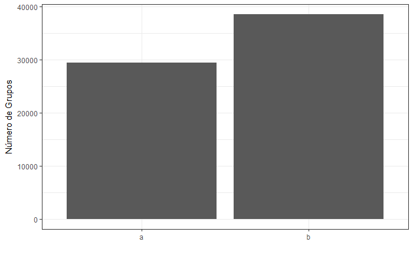

```r
buscas %>%
    distinct(session_id, .keep_all=TRUE) %>%
ggplot() +
  geom_bar(mapping = aes(x = group), stat = "count")  + labs(y="Número de Grupos", x="")
```

```r
buscas %>%
    distinct(session_id, .keep_all=TRUE) %>%
    summarise(TamanhoA = length(which(group=="a")),
TamanhoB = length(which(group=="b")))
```

| TamanhoA | TamanhoB |
| --- | --- |
| 29420 | 38531 |

Quanto a variável **num_clicks_prop**, observando o histograma não fica tão evidente as informações quanto a assimetria dos dados. Contudo, é possível observar que a maioria dos dados estão concentrados a direita indicando que os dados possuem uma assimetria negativa (negative skew), o que é confirmado pelo fato da mediana ser maior que a média e o coeficiente de assimetria ser negativo. Esse comportamento indica a presença de valores discrepantes, o que é confirmado pelo alto desvio padrão apresentado.

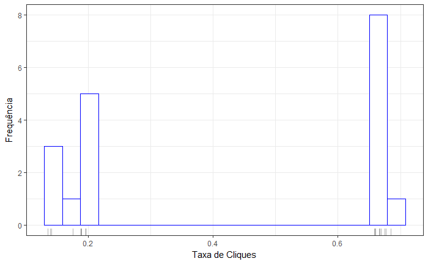

```r
buscas2 = buscas %>%
     distinct(session_id, .keep_all=TRUE) %>%
    count(day, group)
buscas3 = buscas %>%
    filter(num_clicks >= 1) %>%
    distinct(session_id, .keep_all=TRUE) %>%
    count(day, group)
clickthrough_rate <- data.frame(buscas2$day,buscas2$group, buscas2$n, buscas3$n)
colnames(clickthrough_rate) = c("day", "group", "session_total", "visitpage")
clickthrough_rate = clickthrough_rate%>%
    mutate(num_clicks_prop=visitpage/session_total)
clickthrough_rate %>%
    ggplot(aes(x = num_clicks_prop)) +
    geom_histogram(bins = 20, fill = "white", color = "blue")  + geom_rug(alpha = .3) + labs(y="Frequência", x="Taxa de Cliques")
```

```r
clickthrough_rate %>%
 summarise(Assimetria =  skewness(num_clicks_prop),
            Media = mean(num_clicks_prop),
           Mediana = median(num_clicks_prop),
           Desvio = sd(num_clicks_prop),
            Minimo = min(num_clicks_prop),
            Maximo = max(num_clicks_prop))
```

| Assimetria | Media | Mediana | Desvio | Minimo | Maximo |
| --- | --- | --- | --- | --- | --- |
| -0.01279619 | 0.4205458 | 0.427138 | 0.2560385 | 0.1356451 | 0.684689 |

Observando a mediana exibida no boxplot nota-se uma pequena diferença na taxa de cliques em função dos dias. No entanto, devido a variabilidade dos dados não é possível afirmar que há uma alteração na taxa de cliques no decorrer dos dias, pelo contrário, há maiores evidências de que a taxa tende a se manter.

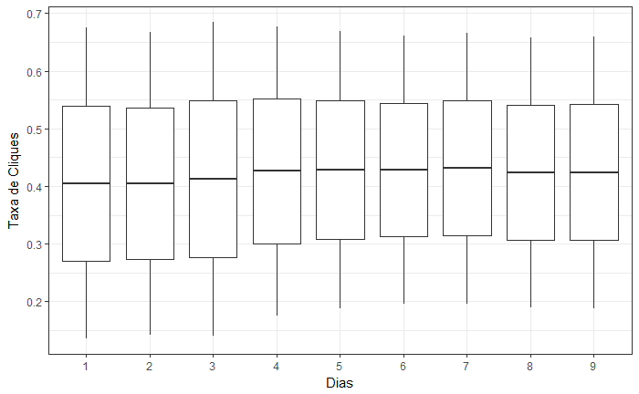

```r
clickthrough_rate  %>% mutate(day = day(day)) %>%
    mutate(day = factor(day, levels = c("1","2","3","4","5","6","7","8","9"))) %>%

    ggplot(clickthrough_rate, mapping = aes(x = day, y = num_clicks_prop))   + geom_boxplot() + labs(y="Taxa de Cliques", x="Dias")
```

Analisando esse comportamento entre os grupos, é possível notar, também, que há pouca variação na taxa de cliques tanto para o grupo A como para o grupo B. Também nota-se que a taxa de cliques é maior para o grupo A (0,66) do que para o grupo B (0,18).

Não se tem conhecimento da diferença entre esses grupos, mas uma possível característica do grupo A pode ter relação com esse comportamento. De toda forma, seria necessário dispor de mais informações para se obter conclusões mais assertivas.

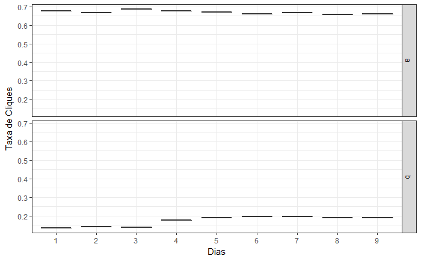

```r
clickthrough_rate  %>% mutate(day = day(day)) %>%
    mutate(day = factor(day, levels = c("1","2","3","4","5","6","7","8","9"))) %>%
    ggplot(clickthrough_rate, mapping = aes(x = day, y = num_clicks_prop))   + geom_boxplot() + facet_grid(group ~ .) + labs(y="Taxa de Cliques", x="Dias")
```

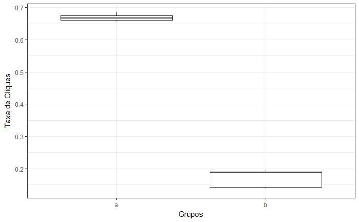

```r
    ggplot(clickthrough_rate, mapping = aes(x = group, y = num_clicks_prop))   +
  geom_boxplot() + labs(y="Taxa de Cliques", x="Grupos")
```

```r
    clickthrough_rate %>%
        group_by(group) %>%
 summarise( Media = mean(num_clicks_prop),
           Mediana = median(num_clicks_prop),
           Desvio = sd(num_clicks_prop),
            Minimo = min(num_clicks_prop),
            Maximo = max(num_clicks_prop))
```

| group | Media | Mediana | Desvio | Minimo | Maximo |
| --- | --- | --- | --- | --- | --- |
| a | 0.6687074 | 0.6675462 | 0.008875731 | 0.6581008 | 0.6846890 |
| b | 0.1723842 | 0.1883013 | 0.025743782 | 0.1356451 | 0.1961751 |

### **2. Quais resultados as pessoas tendem a tentar primeiro? Como isso muda no dia-a-dia?**

Para responder essa pergunta é necessário primeiramente analisar a distribuição da variável **first_click** que retorna qual a posição dos resultados que os usuários tentaram primeiro.

Percebe-se que os resultados estão bem concentrados à esquerda, no entanto, existem valores discrepantes. Observa-se que a mediana é um valor que melhor representa todo o conjunto. O alto desvio padrão indica também a variabilidade dos dados.

Por meio do próprio histograma e do valor da mediana, é possível constatar um comportamento esperado. Os usuários tendem a acessar o primeiro resultado da busca na maioria dos casos. Todavia, não se deve ignorar os valores extremos. Como, por exemplo, existe um caso em que o resultado da 4103º posição foi acessado primeiro. Este é um caso atípico, no entanto, surge a necessidade de maiores investigações para explicar esta ocorrência. Para este caso, pode ter sido usado algum sistema fazendo uso de técnicas de recuperação de informação (deep learning e machine learning), no entanto, são apenas suposições, não há informações suficientes para descrever esse ponto.

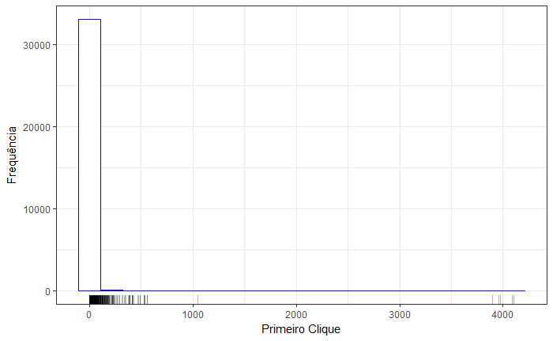

```r
buscas %>%
    ggplot(aes(x = first_click)) +
    geom_histogram(bins = 20, fill = "white", color = "blue")  + geom_rug(alpha = .3) + labs(y="Frequência", x="Primeiro Clique")
```

```r
buscas %>%
 summarise(Media = mean(first_click, na.rm=TRUE),
           Mediana = median(first_click, na.rm=TRUE),
 Desvio = sd(first_click, na.rm=TRUE),
 Minimo = min(first_click,na.rm=TRUE),
Maximo = max(first_click,na.rm=TRUE))
```

| Media | Mediana | Desvio | Minimo | Maximo |
| --- | --- | --- | --- | --- |
| 3.923781 | 1 | 51.86903 | 1 | 4103 |

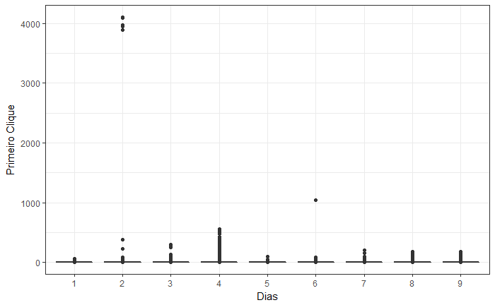

```r
buscas %>%
    mutate(day = day(day)) %>%
    ggplot(buscas, mapping = aes(x = reorder(day,first_click), y = first_click))   +
  geom_boxplot() + labs(y="Primeiro Clique", x="Dias")
```

### **3. Qual é a nossa taxa de resultados zero no geral? Como isso varia entre os grupos?**

Para responder esta pergunta é importante analisar a distribuição da variável **results_zero_prop** que trata-se da proporção de pesquisas que retornou 0 resultados. Observando o histograma não é possível visualizar claramente os dados em termos de viés.

Nota-se uma discreta conscentração dos dados à esqueda, indicando uma assimetria positiva. Que é confirmado pelo fato da média ser maior que a mediana. No entanto, essa assimetria é muito suave, prova disso é que esses valores de tendência central são muito próximos e o desvio padrão é pequeno.

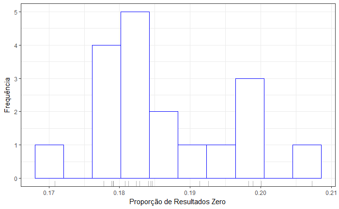

```r
buscas4 = buscas %>%
    count(day, group)
buscas5 = buscas %>%
    filter(results == 0) %>%
    count(day, group)
zero_results_rate <- data.frame(buscas4$day,buscas4$group, buscas4$n, buscas5$n)
colnames(zero_results_rate) = c("day", "group", "session_total", "results_zero")
zero_results_rate = zero_results_rate%>%
    mutate(results_zero_prop=results_zero/session_total)
zero_results_rate %>%
    ggplot(aes(x = results_zero_prop)) +
    geom_histogram(bins = 10, fill = "white", color = "blue")  + geom_rug(alpha = .3) + labs(y="Frequência", x="Proporção de Resultados Zero")
```

```r
zero_results_rate %>%
 summarise(Assimetria =  skewness(results_zero_prop),
           Media = mean(results_zero_prop),
           Mediana = median(results_zero_prop),
           Desvio = sd(results_zero_prop),
            Minimo = min(results_zero_prop),
            Maximo = max(results_zero_prop))
```

| Assimetria | Media | Mediana | Desvio | Minimo | Maximo |
| --- | --- | --- | --- | --- | --- |
| 0.6697172 | 0.1863747 | 0.1834776 | 0.009588103 | 0.1708424 | 0.2072871 |

Analisando o boxplot nota-se que a taxa de resultados zero foi baixa, a máxima taxa apresentada foi 0.20, e a mediana aproximadamente 0.18. Isso significa que a maioria das buscas retornam valores diferentes de zero, o que é um aspecto positivo.

Avaliando em função dos grupos, olhando para as medianas exibidas no boxplot, nota-se que as proporções para o grupo B foram superiores as proporções de resultados zero no grupo A. Todavia, devido a variabilidade dos dados não é possóvel afirmar que haja essa diferença.

De toda forma, para uma análise mais completa seria necessário entender a diferença e características desses grupos, para se buscar e investigar as possíveis causas desse comportamento.

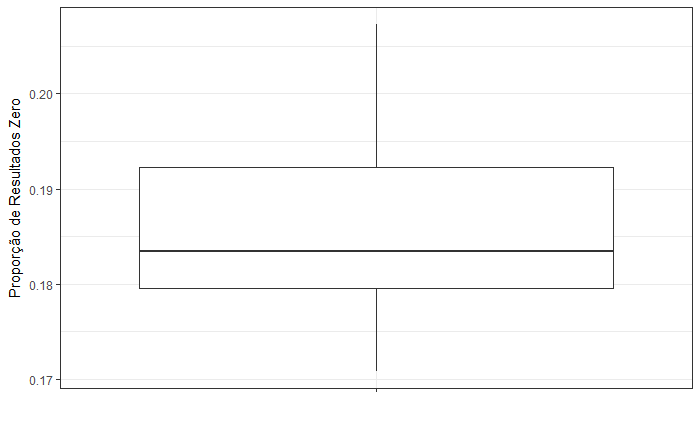

```r
zero_results_rate %>%
    ggplot(zero_results_rate, mapping = aes(x = "", y = results_zero_prop))  + geom_boxplot() + labs(y="Proporção de Resultados Zero", x="")
```

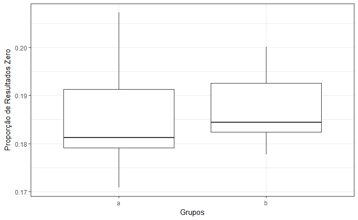

```r
zero_results_rate %>%
    ggplot(zero_results_rate, mapping = aes(x = group, y = results_zero_prop))  + geom_boxplot() + labs(y="Proporção de Resultados Zero", x="Grupos")
```